# Day 2

## Review

- **Population:** the *entire collection* of individuals about which information is sought.
- **Sample:** a *subset* of population, containing the individuals that are actually observed.

### Why do we sample?

**Simple Random Sample**

- A sample chosen by a method where every selection from the population made is **equally likely** to make up the sample

**Stratified Sampling**

- Divide the population into similar groups (i.e., group students by college)
- Randomly sample from those groups (strata)

**Cluster Sampling**

- Divide the population into clusters (i.e., split Manhattan, KS by street block)
- Randomly sample from the clusters

**Systematic Sampling**

- Randomly choose a start point in a “lined-up” population
- Sample every $k^{th}$ item
- i.e., Starting from the $4^{th}$ batch of ice cream produced on a given day, Call Hall will check the quality of every $4^{th}$ batch that comes off the production line

**Voluntary Response Samples**

- Customer support reviews

**Sample of Convenience**

- Class height

**Questions?**

**Goals for Today:**

1. Introduce the fundamental data and variable types
2. Present the *most common* **simple** graphical summaries
3. Differentiate between the use-cases of graphical summaries

## Visualizing Data

### Data

**What is data?**

- **Data:** Information that has been collected
- **Individual:** *Something* the information has been collected on (People/Places/Things/etc.)
- **Variables:** Characteristics about the **individuals** we collected information (**data**) from

$$\begin{array}{|c|c|c|c|c|}
\hline
\text{N} & \text{Age Class} & \text{Weight} & \text{Sex} & \text{Location} \\
\hline
1 & 0.5 & 30.8 & \text{M} & \text{B} \\
\hline
2 & 0.5 & 21.8 & \text{M} & \text{B} \\
\hline
3 & 2.5 & 47.6 & \text{M} & \text{A} \\
\hline
4 & 0.5 & 29.0 & \text{F} & \text{B} \\
\hline
5 & 2.5 & 65.8 & \text{M} & \text{A} \\
\hline
\end{array}$$

$$\begin{array}{|c|c|c|c|c|}
\hline
\text{N} & \text{Treatment} & \text{% Nitrogen} & \text{Replicate} & \text{Stage} & \text{Plot Location}\\
\hline
1 & \text{E} & 1.29 & 4 & \text{P3} & \text{East} \\
\hline
2 & \text{C} & 2.16 & 3 & \text{P2} & \text{West} \\
\hline
3 & \text{C} & 2.33 & 2 & \text{P2} & \text{West} \\
\hline
4 & \text{B} & 1.46 & 3 & \text{P3} & \text{East} \\
\hline
5 & \text{D} & 2.42 & 4 & \text{P1} & \text{West} \\
\hline
6 & \text{A} & 2.14 & 1 & \text{P2} & \text{East} \\
\hline
\end{array}$$

1. How many individuals?
2. What are the variables?
3. What are the data for individual 3?

### Variables

**What’s the difference between column 2 of the soil nitrogen table, and column 3?**

**Qualitative (Categorical) variable:** The value of the variable represents a *descriptive categories*

- Identifying labels/names
- We can’t really do math with a label or name
- We code these into numbers to fix that
  - i.e., Cat-owners = 0 | Dog-owners = 1 | Both = 2

**Quantitative variable:** The value of the variable represents a *meaningful number*

- Height of a person, sales of a product
  - We can do math with these

*A lot of how we do statistics depends on what data we have.*

$$\begin{array}{|c|c|c|c|c|}
\hline
\text{N} & \text{Treatment} & \text{% Nitrogen} & \text{Replicate} & \text{Stage} & \text{Plot Location}\\
\hline
1 & \text{E} & 1.29 & 4 & \text{P3} & \text{East} \\
\hline
2 & \text{C} & 2.16 & 3 & \text{P2} & \text{West} \\
\hline
3 & \text{C} & 2.33 & 2 & \text{P2} & \text{West} \\
\hline
4 & \text{B} & 1.46 & 3 & \text{P3} & \text{East} \\
\hline
5 & \text{D} & 2.42 & 4 & \text{P1} & \text{West} \\
\hline
6 & \text{A} & 2.14 & 1 & \text{P2} & \text{East} \\
\hline
\end{array}$$

> How would you organize Column 2?

> What about Column 6?

Qualitative variables can be **ordinal** or **nominal**

- **Ordinal variables:** Categories/values of the variable have a natural ordering
  - Letter grade: A, B, C, D
  - Clothing size: S, M, L
- **Nominal variable:** Categories/values of the variable cannot be ordered *naturally*
  - State of residence
  - Degree program

Quantitative variables can be **discrete** or **continuous**

- **Discrete variable:** A countable number of values (0, 1, 2, 3, 4, …)
  - Number of students in a classroom
  - Population size of fish in a pond
  - How many times a coin flip was successfully called
- **Continuous variable:** A continuous range of numbers (0, 0.1, 0.11, 0.111, …)
  - Temperature
  - Volume of liquid in a glass
  - Height/Weight

Quantitative variables can be categorized by **level of measurement** used for obtaining data values:

*Interval* level

- Differences between values make sense
- Ratios don’t make sense because **zero has no meaning**
- Temperature in Celsius/Fahrenheit (Does 0 mean there’s no heat?)
- Dates (Is there a meaningful ratio you can make out of 1997 and 2020?)

*Ratio* level

- Numerical measurement
- Differences between values make sense
- Ratios **also make sense**
- Zero **has meaning**, it represents absence of the quantity
- Height (If you’re 0 inches tall, do you have height? Is there a meaningful percentage difference in height between 64 and 67 inches?)

$$\begin{array}{|c|c|c|c|c|}
\hline
\text{Sample ID} & \text{pH} & \text{Temperature} \ (\text{C}^\circ) & \text{Colony Count} & \text{Cholera (+/-)} \\
\hline
1 & 6.89 & 23.6 & 41 & - \\
\hline
2 & 7.19 & 21.2 & 79 & - \\
\hline
3 & 6.98 & 22.1 & 55 & + \\
\hline
4 & 7.31 & 20.4 & 49 & - \\
\hline
5 & 7.02 & 22.7 & 96 & + \\
\hline
\end{array}$$

Categorize the variables:

- pH
- Temperature $(\text{C}^\circ)$
- Colony Count
- Cholera $(+/-)$

### Communicating with Data

**Raw data isn’t entirely useful**

|  | animal | iron | infect | weight | day |
| --- | --- | --- | --- | --- | --- |
| 129 | A06 | Iron | NonInfected | 305 | 508 |
| 509 | A23 | Iron | Infected | 150 | 166 |
| 471 | A21 | Iron | Infected | 230 | 380 |
| 299 | A13 | NoIron | Infected | 410 | 781 |
| 270 | A12 | NoIron | Infected | 295 | 599 |
| 187 | A09 | NoIron | Infected | 130 | 166 |
| 307 | A14 | NoIron | Infected | 200 | 296 |
| 277 | A13 | NoIron | Infected | 125 | 122 |
| 494 | A22 | Iron | Infected | 200 | 380 |
| 330 | A15 | NoIron | Infected | 205 | 296 |

> Statistics is really good at **summarizing** and **visualizing** data

Choosing the “best” graph for displaying our data depends on our data

- What kind of data do we have?
  - Categorical?
  - Numerical?
- What are we trying to do?
  - Describe our sample?
  - Look at the distribution of our data?
  - See how two or more variables are related?
- **Bar graph:** One or more **categorical** variable

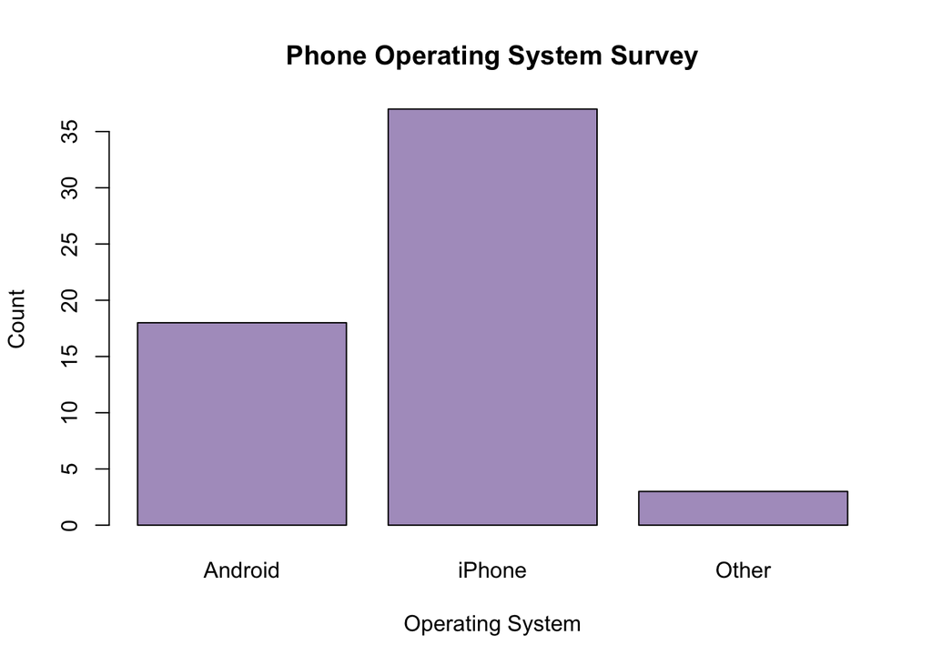

- **Histogram:** One **numerical** variable

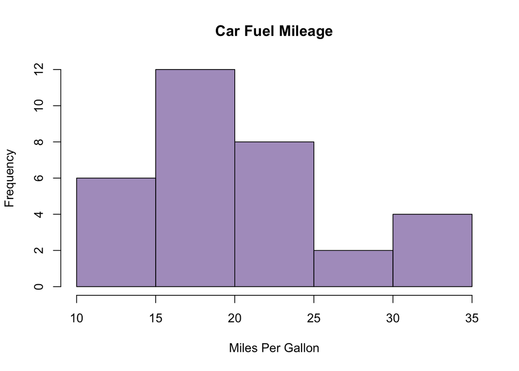

- **Scatterplot:** **More than one** numerical variable

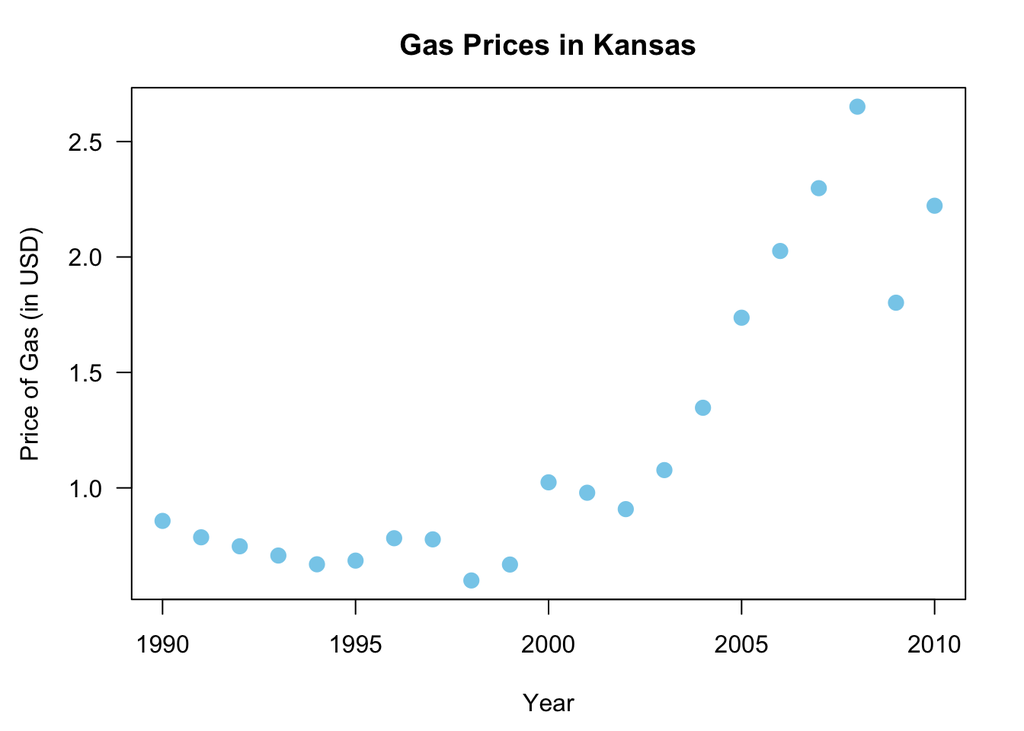

### Summarizing Data

**Even when clean, data is messy**

- Interpreting information is how we make decisions
- Every decision we make is data driven
  - Even when it’s “emotional data”
- Statistics gives us tools to summarize and interpret data rapidly

### Frequency Distribution

$$\begin{array}{|c|c|c|c|c|}
\hline
\text{Sophomore} & \text{Sophomore} & \text{Junior} & \text{Junior} & \text{Sophomore} \\
\hline
\text{Freshman} & \text{Sophomore} & \text{Senior} & \text{Freshman} & \text{Senior} \\
\hline
\end{array}$$

**Random Sample of 10 students in a class**

- How many variables?
- What type of variable?

**Frequency distribution:**

- Groups data into categories
- Records the number of observations that fall into each category
- “How **frequently** do these variables occur in my sample?”

**Relative frequency distribution**

- Divide the number in each category by the total number of observations
- This gives us the **proportion** of units in each category
- “What **percentage** of my sample is represented by this variable?”

Count up how many times each variable occurs in the sample

- For each variable, divide the **occurrences** of the variable by the **sample total**
  - $4$ students are sophomores
  - $10$ students total in the sample
  - ${4 \over 10}=0.40$
  - $0.40*100\%=40\%$

**How is this useful?**

> What percentage of the class drinks coffee?

> What percentage of the class drinks tea?
- Whats our sample?
- Population?
- What are the variables and variable types?

$$\begin{array}{|c|c|c|}
\hline
\text{Drink Preference} & \text{Frequency} & \text{Relative Frequency} \\
\hline
\text{Coffee} & & \\
\hline
\text{Tea} & & \\
\hline
\text{Both} & & \\
\hline
\text{Neither} & & \\
\hline
\text{Total} & & \\
\hline
\end{array}$$

### Bar Graphs

> Why would I want to graph my data?

It looks good.

| Sophomore | Sophomore | Sophomore | Senior | Freshman | Freshman |
| --- | --- | --- | --- | --- | --- |
| Sophomore | Senior | Sophomore | Junior | Sophomore | Senior |
| Junior | Senior | Junior | Freshman | Freshman | Freshman |
| Junior | Junior | Freshman | Sophomore | Junior | Junior |
| Sophomore | Senior | Sophomore | Junior | Sophomore | Freshman |
| Sophomore | Junior | Junior | Sophomore | Sophomore | Senior |

One or more categorical variables

- So we use a **bar graph**

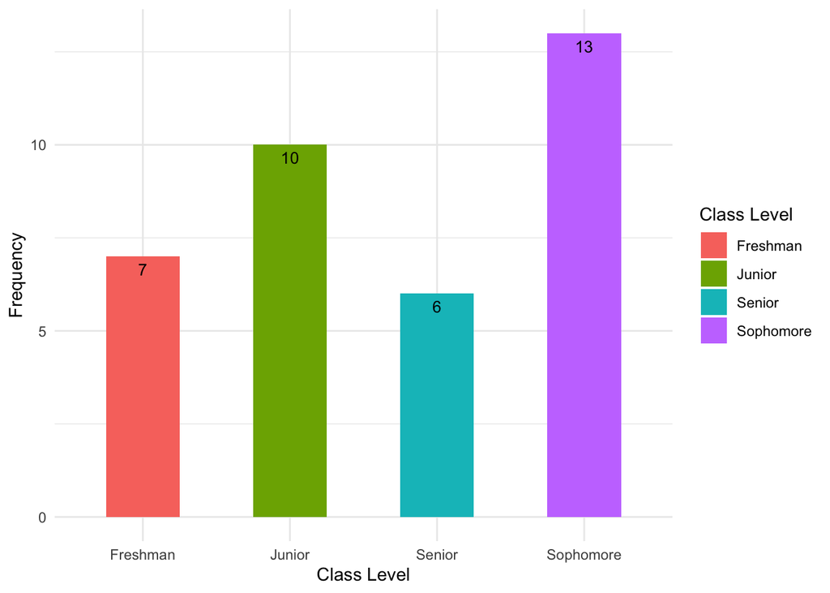

We can also just flip this horizontal

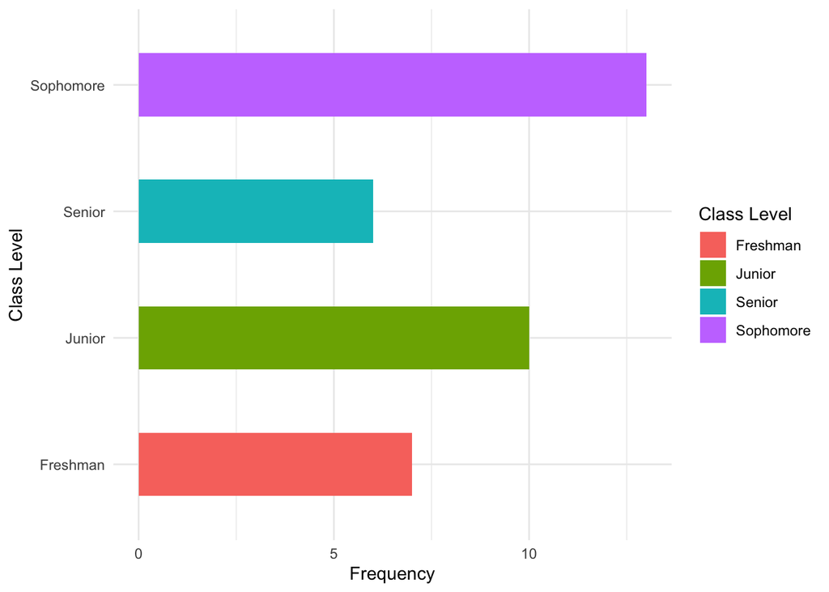

- This is useful for when you have longer category names

### Pie Charts

Bar graphs can be converted into **pie charts:**

Generally a pie chart will show relative frequency

- “What’s my piece of the pie?”

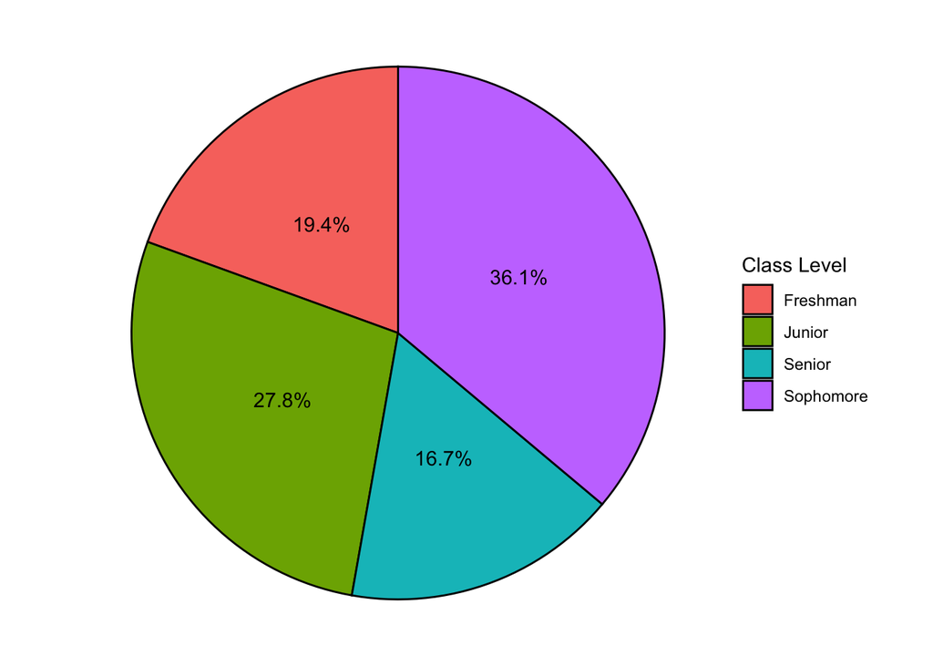

They’re very pretty

- Not extensively useful
- **Interpretability** is everything

### Visualizing Quantitative Data

We’ve looked at some **qualitative** (categorical) visualizations

- What about **quantitative** (numerical) visualizations?
- When we have **one** *quantitative* variable we have several options:
  - **Histograms**
  - **Steam-and-leaf plots**
  - **Dotplots**

With **two** quantitative variables we generally use a **scatterplot**

- We’ll talk about this at length in Chapter 4 (so not important right now)
- Side Note: we can use more than two quantitative variables in a scatterplot
  - It’s not very useful
  - Why? Can you think in 3 dimensions? What about 4? 5?

### Frequency Distribution

- In a study of the yield of corn in varied fertilizers, $54$ values were recorded for yields:

| 46.4 | 140.8 | 103.2 | 94.0 | 98.8 | 109.3 |
| --- | --- | --- | --- | --- | --- |
| 85.2 | 138.2 | 119.0 | 103.1 | 119.8 | 115.8 |
| 110.2 | 139.4 | 102.7 | 100.2 | 130.7 | 110.7 |
| 112.7 | 61.4 | 59.2 | 113.1 | 133.1 | 111.0 |
| 44.4 | 83.3 | 98.1 | 86.6 | 119.0 | 99.8 |
| 63.8 | 106.4 | 106.3 | 109.4 | 128.0 | 112.9 |
| 65.4 | 112.8 | 113.4 | 107.2 | 126.2 | 130.2 |
| 68.1 | 109.1 | 112.6 | 110.6 | 121.0 | 135.5 |
| 131.0 | 85.6 | 67.6 | 106.4 | 119.2 | 135.2 |

- Variables?
- Variable types?

**Quantitative** variables can *also* be summarized with a frequency distribution

- Define interval(s) for the data (referred to as **classes**/**class**)
- Record the number of observations that fall into each class

| Class | 40.0-59.9 | 60.0-79.9 | 80.0-99.9 | 100.0-119.9 | 120.0-139.9 | 140.0+ |
| --- | --- | --- | --- | --- | --- | --- |
| Frequency | 3 | 5 | 8 | 26 | 11 | 1 |

There’s no “one” right way to choose the number of classes or the width for a frequency distribution

### Histograms

**Histogram**: visual representation of a frequency distribution

- **Not a bar graph**

Bar **height** (y-axis) represents **class frequency**

Bar **width** (x-axis) represents **class width**

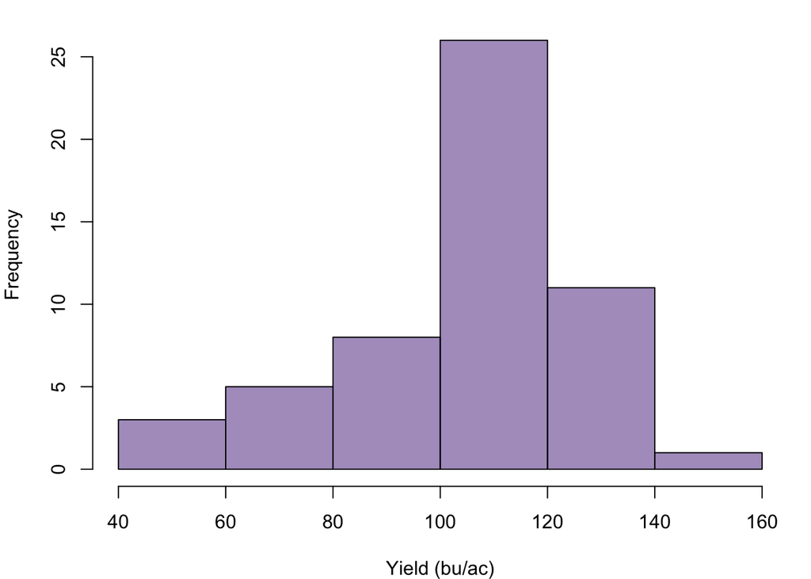

- This histogram has 6 classes
  - You can choose a different number of classes
  - You can choose different widths
  - Free will exists, there are no rules

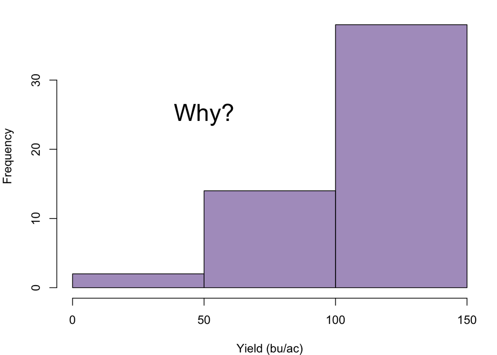

- It’s not wrong (it’s very unhinged behavior)
  - Is this interpretable though?
- We care about the **shape** of our data
  - This is the primary purpose of a histogram
  - So we want to **not** fail at that task
- The shape of our data can help us observe the **distribution** of our data

**Symmetric** - mirror image on both sides of it’s center

**Unimodal** - One peak/hump

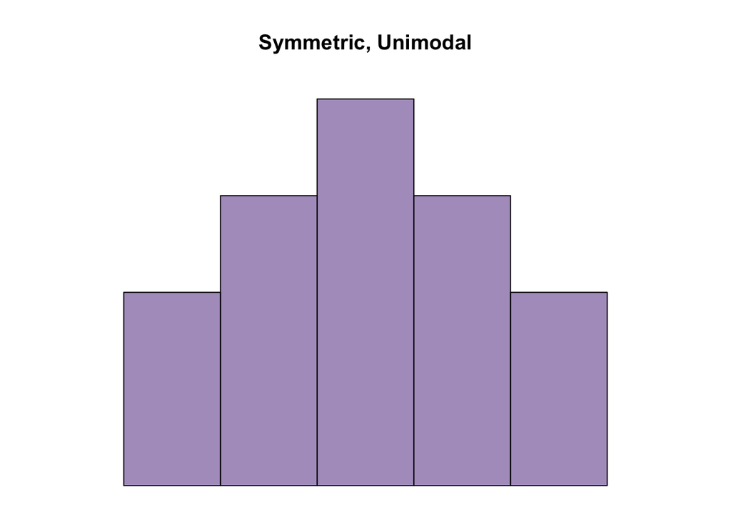

**Positively-skewed** - Long, narrow tail to the **right**

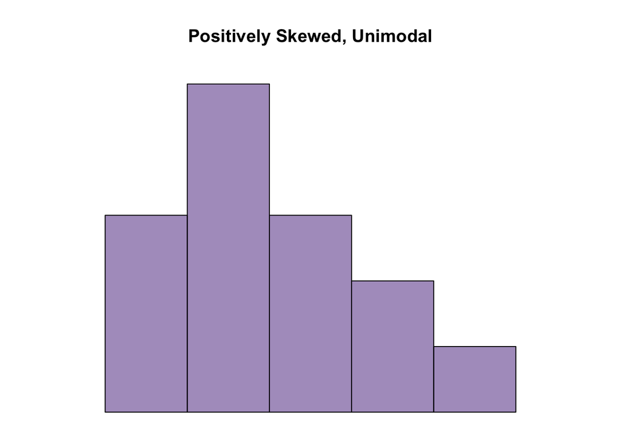

**Negatively-skewed** - Long, narrow tail to the **left**

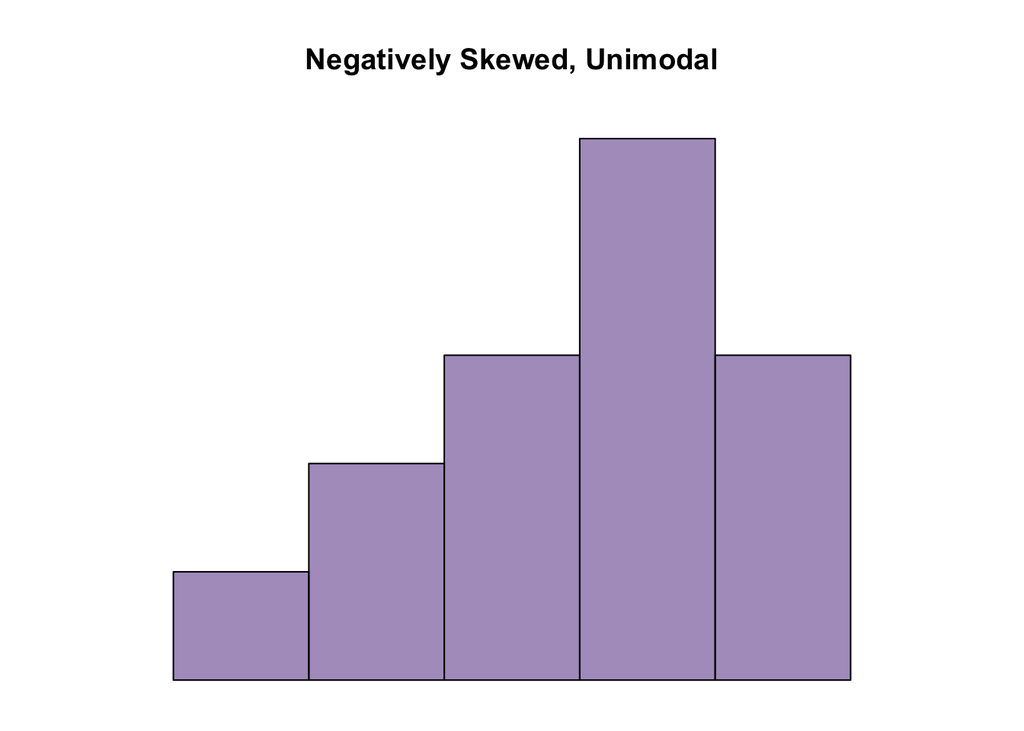

**Uniform** - box

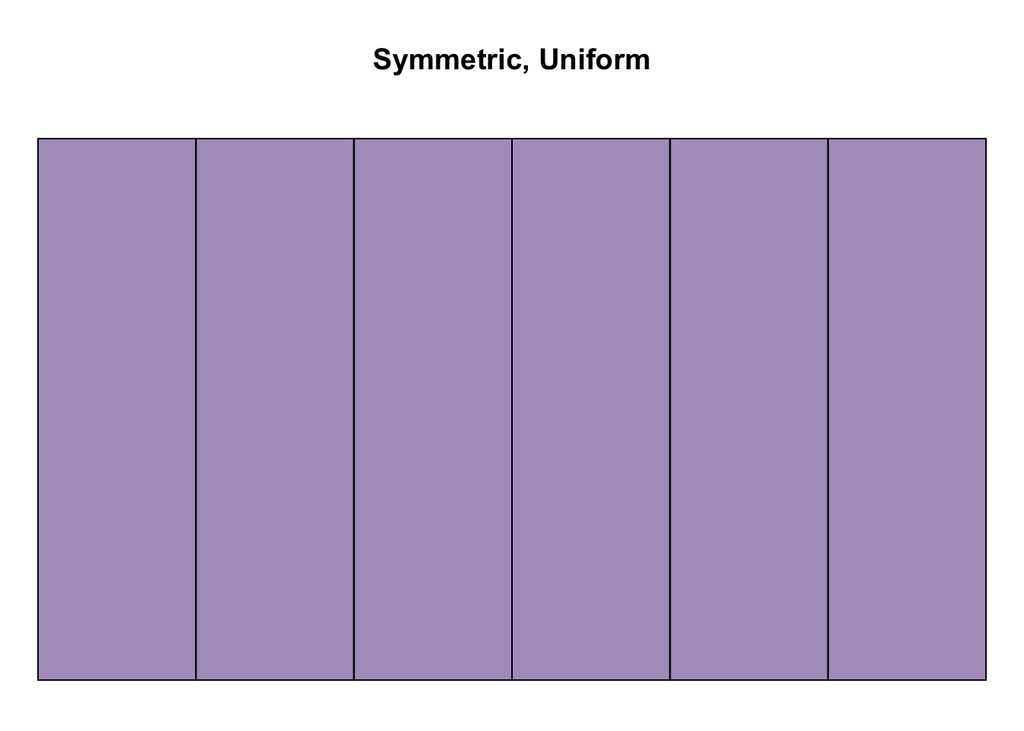

**Bimodal** - two peaks/humps

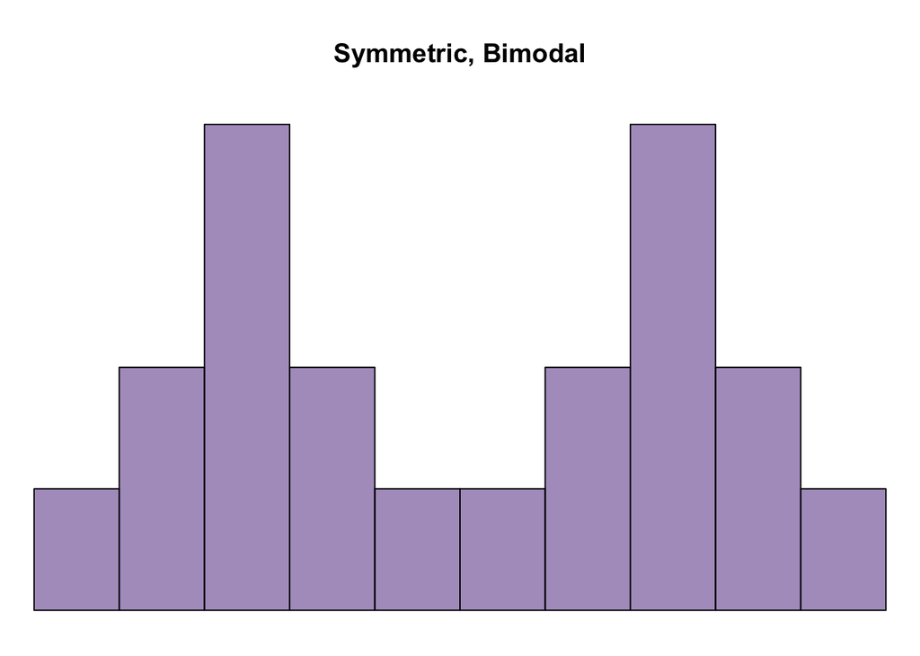

> Histogram showing the GPAs of a sample of students at a certain college

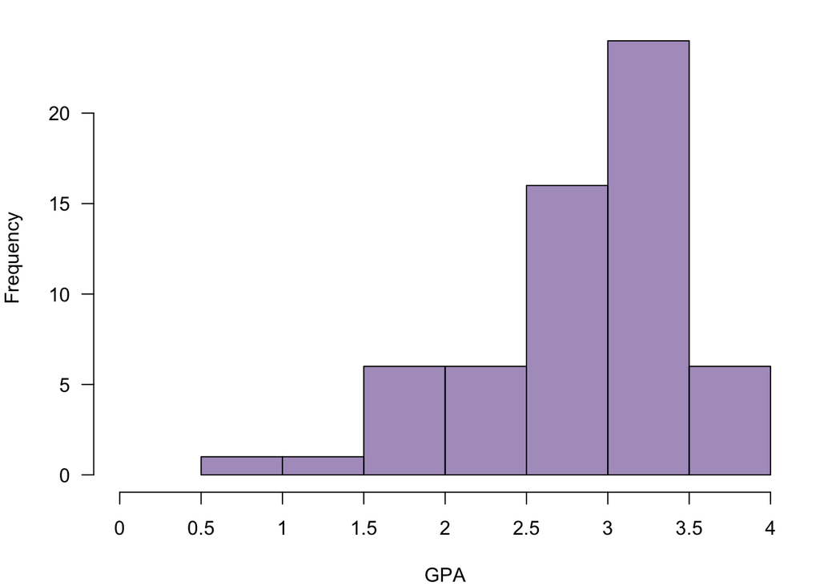

- Which class has the highest frequency?
- How many students were in the sample?
- What percentage of the students had GPAs between 2.0 and 3.0?
- Describe the shape of the above histogram.

> One of these histograms represents the age at death from natual causes, (heart attack, cancer, etc.)

> The other represents the age at death from accidents

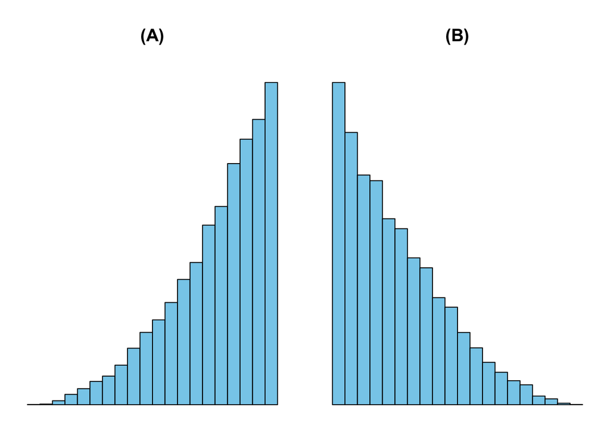

- Which represents the **age at death from accidents**?
  - Justify your answer
- Histograms can be used to summarize both small and large data sets
- Sometimes we prefer more detailed visualizations for smaller data sets
- **Stem-and-leaf plots** and **dotplots** are alternative summaries that display the actual values

### Stem-and-leaf plots

- Each observation should have *at least* **two** digits
  - The digit furthest to the **right** is the “leaf”
  - The digits to the **left** form the “stem”
- The data:

$$\begin{array}{|c|c|c|c|c|c|c|c|c|c|}
\hline
87 & 7 & 95 & 76 & 32 & 28 & 84 & 98 & 93 & 88\\
\hline
78 & 100 & 68 & 76 & 55 & 65 & 42 & 57 & 77 & 96 \\
\hline
\end{array}$$

- The stem-and-leaf plot:

$$\begin{array}{r|l}
0 & 7 \\
1 & \\
2 & 8 \\
3 & 2 \\
4 & 2 \\
5 & 5 \; 7 \\
6 & 5 \; 8 \\
7 & 6 \; 6 \; 7 \; 8 \\
8 & 4 \; 7 \; 8 \\
9 & 3 \; 5 \; 6 \; 8 \\
10 & 0
\end{array}$$

- Can you describe the shape of the data?

### Dotplots

- We can represent each observation by a dot above its value on a number line
- Data:

$$\begin{array}{|c|c|c|c|c|}
\hline
3 & 6 & 2 & 5 & 1 \\
\hline
2 & 3 & 4 & 3 & 4 \\
\hline
\end{array}$$

- Dotplot:

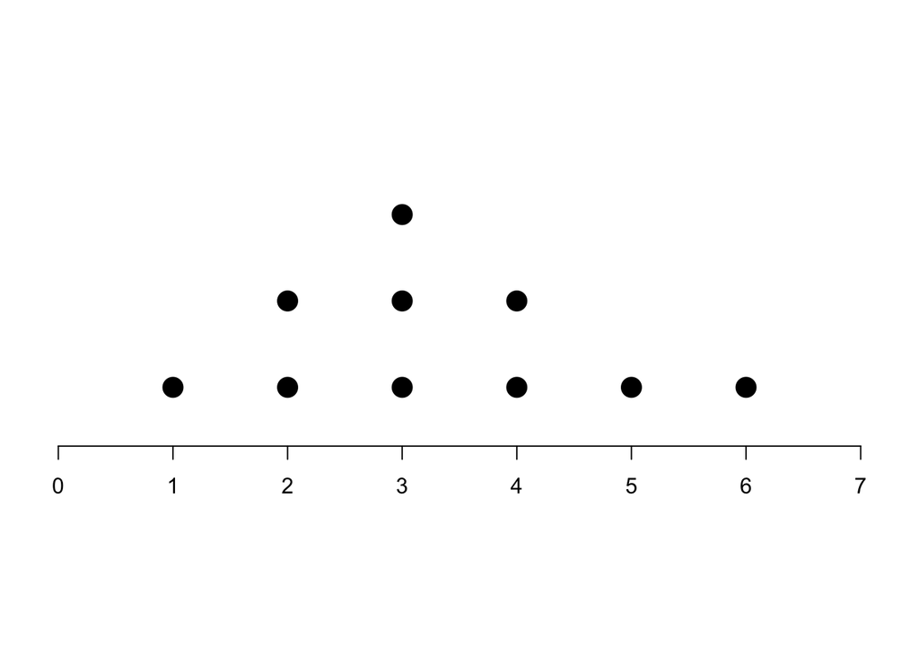

### Time Plots

**As a variable changes over time, we can record that change with a time plot**

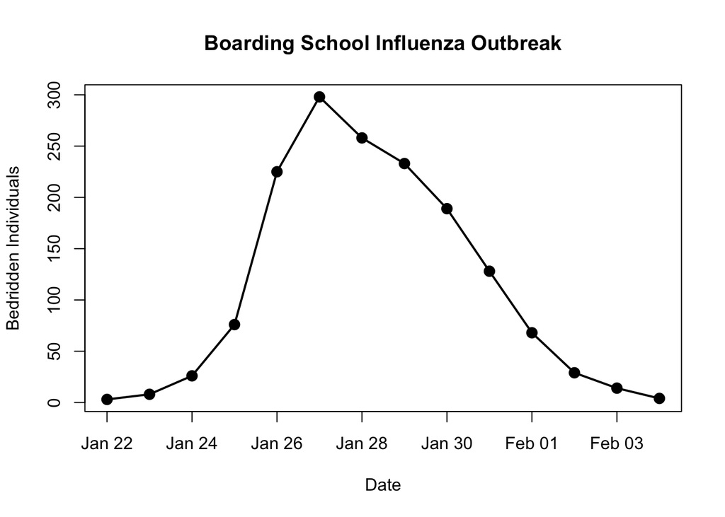

- Time should always be on the horizontal scale
- Your measured variable should be on the vertical scale
- Generally, you want to include points
  - There should typically be a line connecting points

> How many students were bedridden on Jan 30?